Fraud Detection DS Project

*Posted by Yun (Jessica) Yan*

# Setup

```python
import requests, zipfile, io
import numpy as np
import pandas as pd
import matplotlib.pyplot as plt
import seaborn as sns

from sklearn.model_selection import train_test_split
from imblearn.over_sampling import SMOTE
from sklearn.preprocessing import StandardScaler
from sklearn.linear_model import LogisticRegression
from xgboost import XGBClassifier
from xgboost import plot_importance
import sklearn.metrics as metrics
from sklearn.metrics import roc_curve, auc
from sklearn.model_selection import cross_val_score
from bayes_opt import BayesianOptimization

import warnings
warnings.filterwarnings('ignore')

pd.options.display.max_rows = 1000
pd.options.display.max_columns = 60
pd.set_option('display.float_format', lambda x: '%.4f' % x)
```

```python
RANDOMSTATE = 42
```

# Part 1: Load

## Programmatically download the transactions data.

```python
# Download file from Github
url = 'https://raw.githubusercontent.com/CapitalOneRecruiting/DS/master/transactions.zip'
filename = 'transactions.txt'

r = requests.get(url)
z = zipfile.ZipFile(io.BytesIO(r.content))
z.extractall()

# Load the Json file
df = pd.read_json(filename, lines=True)
df.head()
```

|  | accountNumber | customerId | creditLimit | availableMoney | transactionDateTime | transactionAmount | merchantName | acqCountry | merchantCountryCode | posEntryMode | posConditionCode | merchantCategoryCode | currentExpDate | accountOpenDate | dateOfLastAddressChange | cardCVV | enteredCVV | cardLast4Digits | transactionType | echoBuffer | currentBalance | merchantCity | merchantState | merchantZip | cardPresent | posOnPremises | recurringAuthInd | expirationDateKeyInMatch | isFraud |
| --- | --- | --- | --- | --- | --- | --- | --- | --- | --- | --- | --- | --- | --- | --- | --- | --- | --- | --- | --- | --- | --- | --- | --- | --- | --- | --- | --- | --- | --- |
| 0 | 737265056 | 737265056 | 5000 | 5000.0000 | 2016-08-13T14:27:32 | 98.5500 | Uber | US | US | 02 | 01 | rideshare | 06/2023 | 2015-03-14 | 2015-03-14 | 414 | 414 | 1803 | PURCHASE |  | 0.0000 |  |  |  | False |  |  | False | False |
| 1 | 737265056 | 737265056 | 5000 | 5000.0000 | 2016-10-11T05:05:54 | 74.5100 | AMC #191138 | US | US | 09 | 01 | entertainment | 02/2024 | 2015-03-14 | 2015-03-14 | 486 | 486 | 767 | PURCHASE |  | 0.0000 |  |  |  | True |  |  | False | False |
| 2 | 737265056 | 737265056 | 5000 | 5000.0000 | 2016-11-08T09:18:39 | 7.4700 | Play Store | US | US | 09 | 01 | mobileapps | 08/2025 | 2015-03-14 | 2015-03-14 | 486 | 486 | 767 | PURCHASE |  | 0.0000 |  |  |  | False |  |  | False | False |
| 3 | 737265056 | 737265056 | 5000 | 5000.0000 | 2016-12-10T02:14:50 | 7.4700 | Play Store | US | US | 09 | 01 | mobileapps | 08/2025 | 2015-03-14 | 2015-03-14 | 486 | 486 | 767 | PURCHASE |  | 0.0000 |  |  |  | False |  |  | False | False |
| 4 | 830329091 | 830329091 | 5000 | 5000.0000 | 2016-03-24T21:04:46 | 71.1800 | Tim Hortons #947751 | US | US | 02 | 01 | fastfood | 10/2029 | 2015-08-06 | 2015-08-06 | 885 | 885 | 3143 | PURCHASE |  | 0.0000 |  |  |  | True |  |  | False | False |

## Describe the structure of the data. Number of records and fields in each record?

- The data has 786363 records and 29 fields in each record.
- We have 4 numerical features, 4 date variables, and 21 categorical variables (including 3 boolean variables).

  **Categorical Variables:**
  - *Target Variable:* isFraud
  - *Unique Identifier for customers:* accountNumber, customerId,
  - *Merchant Info:* merchantName, merchantCity, merchantState, merchantZip, merchantCountryCode, merchantCategoryCode
  - *Card Info:* cardCVV, enteredCVV, cardLast4Digits, cardPresent
  - *Pos Info:* posEntryMode, posConditionCode, posOnPremises
  - *Transaction Info:* transactionType
  - *Others:* acqCountry, echoBuffer, recurringAuthInd, expirationDateKeyInMatch

  **Numerical Variables:** creditLimit, availableMoney, transactionAmount, currentBalance

  **Date Variables:** transactionDateTime, currentExpDate, accountOpenDate, dateOfLastAddressChange

```python
# There are lots of blank cells in the dataset, so I convert them into "NaN".
df.replace('', np.nan, inplace=True)
```

```python
# Total number of rows and columns
print("""Total number of rows: %s
Total number of columns: %s"""%(df.shape[0], df.shape[1]))
```

```
Total number of rows: 786363
Total number of columns: 29
```

## Generate some basic summary statistics for each field.

By checking the missing values for each columns, we can see that 6 columns (**echoBuffer, recurringAuthInd, posOnPremises, merchantCity, merchantState, and merchantZip**) from our dataset are 100% missing. I would like to drop them since they are not able to provide any value to our analysis and model.

Besides, I would also want to drop either **accountNumber** or **customerId** because they are identical. I choose to drop **accountNumber** here.

Lastly, there are another 5 columns (**acqCountry, posEntryMode, merchantCountryCode, transactionType, posConditionCode**) with 0.05% - 0.5% missing. Some imputations are probably needed. As they are all categorical variables, I would like to fill in "Missing" for missing values to keep the original distribution of the data and avoid any bias.

```python
# Missing Values
df.isnull().sum().sort_values(ascending=False)
```

```
echoBuffer                  786363
merchantCity                786363
recurringAuthInd            786363
posOnPremises               786363
merchantZip                 786363
merchantState               786363
acqCountry                    4562
posEntryMode                  4054
merchantCountryCode            724
transactionType                698
posConditionCode               409
creditLimit                      0
availableMoney                   0
transactionDateTime              0
transactionAmount                0
merchantName                     0
customerId                       0
isFraud                          0
dateOfLastAddressChange          0
merchantCategoryCode             0
currentExpDate                   0
accountOpenDate                  0
expirationDateKeyInMatch         0
cardCVV                          0
enteredCVV                       0
cardLast4Digits                  0
currentBalance                   0
cardPresent                      0
accountNumber                    0
dtype: int64
```

```python
# Drop either accountNumber or customerId because they are identical
len(df[df['accountNumber'] != df['customerId']])
```

```
0
```

```python
# Drop accountNumber and columns with 100% missing values
df.drop(['accountNumber','echoBuffer', 'recurringAuthInd', 'posOnPremises', 'merchantCity', 'merchantState','merchantZip'], axis=1, inplace=True)
df = df.reset_index(drop=True)
```

```python
df.drop_duplicates(inplace=True)
```

```python
# Check the current data type for all columns
df.info()
```

```
<class 'pandas.core.frame.DataFrame'>
RangeIndex: 786363 entries, 0 to 786362
Data columns (total 22 columns):
 #   Column                    Non-Null Count   Dtype
---  ------                    --------------   -----
 0   customerId                786363 non-null  int64
 1   creditLimit               786363 non-null  int64
 2   availableMoney            786363 non-null  float64
 3   transactionDateTime       786363 non-null  object
 4   transactionAmount         786363 non-null  float64
 5   merchantName              786363 non-null  object
 6   acqCountry                781801 non-null  object
 7   merchantCountryCode       785639 non-null  object
 8   posEntryMode              782309 non-null  object
 9   posConditionCode          785954 non-null  object
 10  merchantCategoryCode      786363 non-null  object
 11  currentExpDate            786363 non-null  object
 12  accountOpenDate           786363 non-null  object
 13  dateOfLastAddressChange   786363 non-null  object
 14  cardCVV                   786363 non-null  int64
 15  enteredCVV                786363 non-null  int64
 16  cardLast4Digits           786363 non-null  int64
 17  transactionType           785665 non-null  object
 18  currentBalance            786363 non-null  float64
 19  cardPresent               786363 non-null  bool
 20  expirationDateKeyInMatch  786363 non-null  bool
 21  isFraud                   786363 non-null  bool
dtypes: bool(3), float64(3), int64(5), object(11)
memory usage: 116.2+ MB
```

```python
# Make sure that every column is in the most suitable data type.

#df['accountNumber'] = df['accountNumber'].astype('object')
df['customerId'] = df['customerId'].astype('object')
df['transactionDateTime'] = df['transactionDateTime'].astype('datetime64[ns]')
df['currentExpDate'] = df['currentExpDate'].astype('datetime64[D]')
df['accountOpenDate'] = df['accountOpenDate'].astype('datetime64[D]')
df['dateOfLastAddressChange'] = df['dateOfLastAddressChange'].astype('datetime64[D]')
df['cardCVV'] = df['cardCVV'].astype('object')
df['enteredCVV'] = df['enteredCVV'].astype('object')
df['cardLast4Digits'] = df['cardLast4Digits'].astype('object')
```

```python
# Create a summary statistics
df.describe(include='all')
```

|  | customerId | creditLimit | availableMoney | transactionDateTime | transactionAmount | merchantName | acqCountry | merchantCountryCode | posEntryMode | posConditionCode | merchantCategoryCode | currentExpDate | accountOpenDate | dateOfLastAddressChange | cardCVV | enteredCVV | cardLast4Digits | transactionType | currentBalance | cardPresent | expirationDateKeyInMatch | isFraud |
| --- | --- | --- | --- | --- | --- | --- | --- | --- | --- | --- | --- | --- | --- | --- | --- | --- | --- | --- | --- | --- | --- | --- |
| count | 786363.0000 | 786363.0000 | 786363.0000 | 786363 | 786363.0000 | 786363 | 781801 | 785639 | 782309 | 785954 | 786363 | 786363 | 786363 | 786363 | 786363.0000 | 786363.0000 | 786363.0000 | 785665 | 786363.0000 | 786363 | 786363 | 786363 |
| unique | 5000.0000 | nan | nan | 776637 | nan | 2490 | 4 | 4 | 5 | 3 | 19 | 165 | 1820 | 2184 | 899.0000 | 976.0000 | 5245.0000 | 3 | nan | 2 | 2 | 2 |
| top | 380680241.0000 | nan | nan | 2016-05-28 14:24:41 | nan | Uber | US | US | 05 | 01 | online_retail | 2029-03-01 00:00:00 | 2014-06-21 00:00:00 | 2016-03-15 00:00:00 | 869.0000 | 869.0000 | 593.0000 | PURCHASE | nan | False | False | False |
| freq | 32850.0000 | nan | nan | 4 | nan | 25613 | 774709 | 778511 | 315035 | 628787 | 202156 | 5103 | 33623 | 3819 | 33749.0000 | 33424.0000 | 32946.0000 | 745193 | nan | 433495 | 785320 | 773946 |
| first | nan | nan | nan | 2016-01-01 00:01:02 | nan | NaN | NaN | NaN | NaN | NaN | NaN | 2019-12-01 00:00:00 | 1989-08-22 00:00:00 | 1989-08-22 00:00:00 | nan | nan | nan | NaN | nan | NaN | NaN | NaN |
| last | nan | nan | nan | 2016-12-30 23:59:45 | nan | NaN | NaN | NaN | NaN | NaN | NaN | 2033-08-01 00:00:00 | 2015-12-31 00:00:00 | 2016-12-30 00:00:00 | nan | nan | nan | NaN | nan | NaN | NaN | NaN |
| mean | nan | 10759.4645 | 6250.7254 | NaN | 136.9858 | NaN | NaN | NaN | NaN | NaN | NaN | NaN | NaN | NaN | nan | nan | nan | NaN | 4508.7391 | NaN | NaN | NaN |
| std | nan | 11636.1749 | 8880.7840 | NaN | 147.7256 | NaN | NaN | NaN | NaN | NaN | NaN | NaN | NaN | NaN | nan | nan | nan | NaN | 6457.4421 | NaN | NaN | NaN |
| min | nan | 250.0000 | -1005.6300 | NaN | 0.0000 | NaN | NaN | NaN | NaN | NaN | NaN | NaN | NaN | NaN | nan | nan | nan | NaN | 0.0000 | NaN | NaN | NaN |
| 25% | nan | 5000.0000 | 1077.4200 | NaN | 33.6500 | NaN | NaN | NaN | NaN | NaN | NaN | NaN | NaN | NaN | nan | nan | nan | NaN | 689.9100 | NaN | NaN | NaN |
| 50% | nan | 7500.0000 | 3184.8600 | NaN | 87.9000 | NaN | NaN | NaN | NaN | NaN | NaN | NaN | NaN | NaN | nan | nan | nan | NaN | 2451.7600 | NaN | NaN | NaN |
| 75% | nan | 15000.0000 | 7500.0000 | NaN | 191.4800 | NaN | NaN | NaN | NaN | NaN | NaN | NaN | NaN | NaN | nan | nan | nan | NaN | 5291.0950 | NaN | NaN | NaN |
| max | nan | 50000.0000 | 50000.0000 | NaN | 2011.5400 | NaN | NaN | NaN | NaN | NaN | NaN | NaN | NaN | NaN | nan | nan | nan | NaN | 47498.8100 | NaN | NaN | NaN |

I have included all columns in the summary statistics above.

- For numerical columns: count, mean, std, min, 25%, 50%, 75%, max
- For categorical columns: count, unique, top, freq
- For date columns: count, unique, top, freq, first, last

Based on the results, we learned that:

- The data are transaction data in 2016 (from 2016/01/01 to 2016/12/30)
- The target variable is `isFraud`. 98.42% of its value is `False` and 1.58% is `True`.
- The distribution of 4 numerical features are all skewed to right since their mean value is greatly higher than the median value (50%)

# Part 2: Plot

## Plot a histogram of the processed amounts of each transaction, the transactionAmount column.

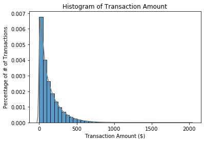

```python
#sns.histplot(df['transactionAmount'], kde=True, binwidth=50)
sns.histplot(df['transactionAmount'], binwidth=50, stat="density")
sns.kdeplot(df['transactionAmount'], color="gray")
# Add labels
plt.title('Histogram of Transaction Amount')
plt.xlabel('Transaction Amount ($)')
plt.ylabel('Percentage of # of Transactions')
plt.show()
```

We can see that there are some outliers in the above histogram. Thus, I then detect and remove them from the data and create an updated histogram. We probably also want to consider removing outliers in the modeling stage.

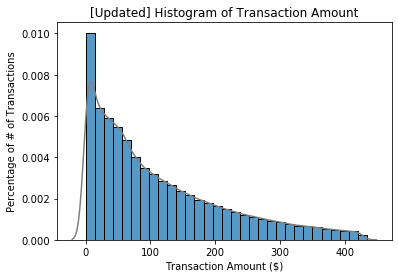

```python
# Remove outliers which are greater than Q3 + 1.5IQR
q1, q3 = np.percentile(sorted(df['transactionAmount']),[25,75])
iqr = q3 - q1
upper_bound = q3 + (1.5 * iqr)
df_no_outlier = df[df['transactionAmount'] <= upper_bound][['transactionAmount']]

sns.histplot(df_no_outlier, x="transactionAmount", binwidth=14, stat="density")
sns.kdeplot(df_no_outlier['transactionAmount'], color="gray")

# Add labels
plt.title('[Updated] Histogram of Transaction Amount')
plt.xlabel('Transaction Amount ($)')
plt.ylabel('Percentage of # of Transactions')
plt.show()
```

In order to understand the distribution of transactionAmount for fraud and non-fraud transactionAmount, I have created the following graph.

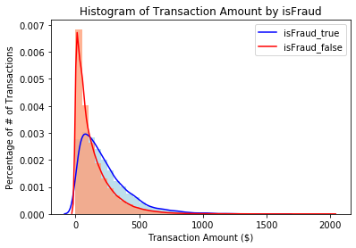

```python
isFraud_True = df.loc[df.isFraud==True, 'transactionAmount']
isFraud_False = df.loc[df.isFraud==False, 'transactionAmount']

fig, ax1 = plt.subplots()
sns.histplot(isFraud_True, binwidth=50, stat="density", color="lightblue", alpha = 0.8,edgecolor='none', ax=ax1)
sns.histplot(isFraud_False, binwidth=50, stat="density", color="lightsalmon", alpha = 0.8,edgecolor='none', ax=ax1)
sns.kdeplot(isFraud_True , color="blue", label="isFraud_true", ax=ax1)
sns.kdeplot(isFraud_False, color="red", label="isFraud_false", ax=ax1)
plt.title('Histogram of Transaction Amount by isFraud')
plt.xlabel('Transaction Amount ($)')
plt.ylabel('Percentage of # of Transactions')
plt.legend()
plt.show()
```

```python
isFraud_True.describe()
```

```
count   12417.0000
mean      225.2159
std       189.5514
min         0.0000
25%        86.0000
50%       176.9800
75%       311.4600
max      1608.3500
Name: transactionAmount, dtype: float64
```

```python
isFraud_False.describe()
```

```
count   773946.0000
mean       135.5702
std        146.5253
min          0.0000
25%         33.1900
50%         86.7600
75%        189.3900
max       2011.5400
Name: transactionAmount, dtype: float64
```

## Some hypotheses about the data structure...

- The histogram above aligns with our assumption above that the distribution of numerical variables is right-skewed.
- Most of transactions fall in the range of \$0 to \$500. 53.88% is less than \$100, and 10.75% of the transaction amount is only less than \$10.
- Based on the histogram by isFraud, we can see that the trend is different between fraud and non-fraud transactions.
  - The distribution of non-fraud transactions is more skewed to the right than the distribution of fraud transaction, which means that fraud transactions tend to involve more money.
  - Looking at the summary stats, the average amount for fraud transactions is \$225 while the average non-fraud transaction amount is \$135.
  - 50% of non-fraud transactions has amount less than \$87 while only 25% of fraud transactions has amount less than \$87.
  - Although the non-fraud transactions are mostly small amount, the maximum transaction amount for non-fraud transactions (\$2011) is much higher than the maximum transaction amount for fraud transactions (\$1608).

Thus, according to the analysis above, we can make the hypothese that fraudsters tend to make transactions with small to medium amount. It is less likely to be a very small amount because it is not attractive enough for fraudsters to take the risk. It is also less likely to be a very big amount because it would then be too noticable and risky. Note that the fraud transaction is only 1.58% of all transactions. It is possible that it is not representative enough. We might want more records to valid our analysis here. We will discuss this in the last section of this report.

# Part 3: Data Wrangling - Duplicate Transactions

I noticed a number of what look like duplicated transactions in the data set. One type of duplicated transaction is a reversed transaction, where a purchase is followed by a reversal. Another example is a multi-swipe, where a vendor accidentally charges a customer's card multiple times within a short time span. Here are some questions I tried to answer:

• Can we programmatically identify reversed and multi-swipe transactions?

• What total number of transactions and total dollar amount do we estimate for the reversed transactions? For the multi-swipe transactions? (consider the first transaction to be "normal" and exclude it from the number of transaction and dollar amount counts)

• Did we find anything interesting about either kind of transaction?

## Preparation: Create Unique Key Column

```python
# Create a unique key column to ensure each row has a unique id
df['transactionKey']=df.reset_index().index
```

## Reversed Transactions

If we filter the data by transactionType == 'REVERSAL', we would get **20,303** reversal transactions, and the total amount is **\$2,821,792.5**.

Ideally, each reversal transaction should be able to match with a normal purchase transaction based on the following criteria:

- The reversal transaction and the matched purchase transaction have the same customerId, transactionAmount, merchantName, and cardLast4Digits.
- The reversal transaction happens later than the matched purchase transaction.

With the 2 criteria, I tried to match a normal purchase transaction with each reversal transaction:

- **Step 1:** Create 2 seperate datasets purchase and reversal from the original dataset, one containing all purchasing records and the other containing all reversal records.
- **Step 2:** Left join the 2 data set (left: reversal, right: purchase) by customerId, transactionAmount, merchantName, and cardLast4Digits. Basically, I was trying to find a matched purchase transaction for each reversal transaction.
- **Step 3:** Filter for matched transactions which the purchase transaction time is earlier than the reversal transaction time
- **Step 4:** Both purchase and reversal data have some duplicates and will over-estimate the result if joining together (e.g. There will be multiple purchase transactions with the same amount if it is recurring). Thus, we split the data from step 3 into two parts.
  - One includes the matched transactions of which both reversal and purchase transactions are only used once. This part is considered done and these transactions will be removed from the original purchase and reversal data sets for the following steps.
  - Another part contains matched transactions of which either reversal or purchase transactions are used more than once. We still need to find a matched purchase transaction for the rest of reversal transactions.
- **Step 5:** Use a for loop scan to find the latest purchase transactions that fulfills the two criterias mentioned above for each reversal transaction.
- **Step 6:** Combine the result from step 5 and the first part of data from step 4 to get the final results.

We can see that for all **20,303** reversal transactions with total amount as **\$2,821,792.5**.

- I am able to match the normal purchase transactions to **17,756** reversal transactions with total amount as **\$2,666,167.82**.
- I am not able to match the normal purchase transactions to the rest of **2,547** reversal transactions with total amount as **\$155,624.68**.

The possible reasons for the **2,547** reversal transactions that can't be matched are:

1. Data Quality: Some Transaction Data is missing from the available data set.
2. Different Transaction Amount: The transaction amount is different in the purchase and reversal transactions.

```python
df.groupby(df['transactionType'].fillna('Missing')).agg({'customerId':'count','transactionAmount':'sum','isFraud':'mean'}).reset_index()
```

|  | transactionType | customerId | transactionAmount | isFraud |
| --- | --- | --- | --- | --- |
| 0 | ADDRESS_VERIFICATION | 20169 | 0.0000 | 0.0058 |
| 1 | Missing | 698 | 108459.7800 | 0.0201 |
| 2 | PURCHASE | 745193 | 104790305.2500 | 0.0160 |
| 3 | REVERSAL | 20303 | 2821792.5000 | 0.0166 |

```python
purchase = df[df['transactionType'] == 'PURCHASE'].copy()
reversal = df[df['transactionType'] == 'REVERSAL'].copy()
```

```python
reversal_match = pd.merge(reversal, purchase, on=['customerId', 'transactionAmount', 'merchantName','cardLast4Digits'], how='left')
reversal_match.loc[(reversal_match['isFraud_y'].isna() == True) | (reversal_match['transactionDateTime_y'] > reversal_match['transactionDateTime_x']), 'Match'] = 0
reversal_match.loc[reversal_match['Match'].isna() == True, 'Match'] = 1
```

```python
reversal.head()
```

|  | customerId | creditLimit | availableMoney | transactionDateTime | transactionAmount | merchantName | acqCountry | merchantCountryCode | posEntryMode | posConditionCode | merchantCategoryCode | currentExpDate | accountOpenDate | dateOfLastAddressChange | cardCVV | enteredCVV | cardLast4Digits | transactionType | currentBalance | cardPresent | expirationDateKeyInMatch | isFraud | transactionKey |
| --- | --- | --- | --- | --- | --- | --- | --- | --- | --- | --- | --- | --- | --- | --- | --- | --- | --- | --- | --- | --- | --- | --- | --- |
| 39 | 574788567 | 2500 | 2200.9800 | 2016-05-24 01:38:03 | 215.1300 | Convenient Tire | US | US | 09 | 01 | auto | 2021-10-01 | 2015-10-13 | 2015-10-13 | 206 | 206 | 8522 | REVERSAL | 299.0200 | True | False | False | 39 |
| 73 | 574788567 | 2500 | 2432.7200 | 2016-10-07 10:23:57 | 3.8700 | Eazy Repair | US | US | 05 | 01 | auto | 2022-10-01 | 2015-10-13 | 2015-10-13 | 579 | 579 | 4219 | REVERSAL | 67.2800 | True | False | False | 73 |
| 101 | 924729945 | 50000 | 49831.4300 | 2016-10-19 14:01:45 | 168.5700 | discount.com | US | US | 05 | 01 | online_retail | 2024-11-01 | 2014-07-25 | 2014-07-25 | 205 | 265 | 9459 | REVERSAL | 168.5700 | False | False | False | 101 |
| 133 | 984504651 | 50000 | 46367.4100 | 2016-01-16 09:53:15 | 450.7400 | Planet Fitness #849960 | US | US | 05 | 01 | health | 2028-08-01 | 2015-07-27 | 2015-07-27 | 640 | 640 | 8332 | REVERSAL | 3632.5900 | False | False | False | 133 |
| 156 | 984504651 | 50000 | 41909.3000 | 2016-01-25 20:39:15 | 81.7300 | AMC #724446 | US | US | 09 | 01 | entertainment | 2031-12-01 | 2015-07-27 | 2015-07-27 | 640 | 640 | 8332 | REVERSAL | 8090.7000 | True | False | False | 156 |

```python
xkey=reversal_match.groupby(['transactionKey_x']).agg({'customerId':'count'}).reset_index()
ykey=reversal_match.groupby(['transactionKey_y']).agg({'customerId':'count'}).reset_index()
xkey1=xkey[xkey['customerId'] > 1]['transactionKey_x'].to_list()
ykey1=ykey[ykey['customerId'] > 1]['transactionKey_y'].to_list()
reversal_match_new = reversal_match[(~reversal_match['transactionKey_x'].isin(xkey1)) & (~reversal_match['transactionKey_y'].isin(ykey1))]
purchase_new = purchase[(~purchase['transactionKey'].isin(reversal_match_new['transactionKey_y'].to_list()))]
reversal_new = reversal[(~reversal['transactionKey'].isin(reversal_match_new['transactionKey_x'].to_list()))]
#len(reversal_new)
```

```python
reversal_new = reversal_new.sort_values(['customerId','transactionDateTime']).copy()
purchase1 = purchase_new.copy()
df1 = pd.DataFrame(columns = reversal.columns)

for i in range(len(reversal_new)):
    customerId = reversal_new.iloc[i,0]
    transactionAmount = reversal_new.iloc[i,4]
    merchantName = reversal_new.iloc[i,5]
    transactionDateTime = reversal_new.iloc[i,3]
    a = purchase1[(purchase1['customerId']==customerId) & (purchase1['transactionAmount']==transactionAmount) & (purchase1['merchantName']== merchantName) & (purchase1['transactionDateTime'] <= transactionDateTime)].sort_values(['transactionDateTime'],ascending=False).head(1)
    i = purchase1[(purchase1['customerId']==customerId) & (purchase1['transactionAmount']==transactionAmount) & (purchase1['merchantName']== merchantName) & (purchase1['transactionDateTime'] <= transactionDateTime)].sort_values(['transactionDateTime'],ascending=False).index
    if i.size > 0:
        df1 = df1.append(a, ignore_index=True)
    else:
        df1 = df1.append(pd.Series(dtype=object), ignore_index=True)

    purchase1.drop(i, inplace=True)
```

```python
reversal_new.reset_index(inplace=True)
reversal_new.reset_index(inplace=True)
df1.reset_index(inplace=True)
df1.reset_index(inplace=True)

reversal_match_new2 = pd.merge(reversal_new, df1, on=['level_0','customerId', 'transactionAmount', 'merchantName','cardLast4Digits'], how='left')
reversal_match_new2.loc[(reversal_match_new2['isFraud_y'].isna() == True), 'Match'] = 0
reversal_match_new2.loc[reversal_match_new2['Match'].isna() == True, 'Match'] = 1
reversal_match_new2.drop(['level_0', 'index_x','index_y'], axis=1,inplace=True)
```

```python
reversal_match_final = pd.concat([reversal_match_new, reversal_match_new2])
reversal_match_final.head()
```

|  | customerId | creditLimit_x | availableMoney_x | transactionDateTime_x | transactionAmount | merchantName | acqCountry_x | merchantCountryCode_x | posEntryMode_x | posConditionCode_x | merchantCategoryCode_x | currentExpDate_x | accountOpenDate_x | dateOfLastAddressChange_x | cardCVV_x | enteredCVV_x | cardLast4Digits | transactionType_x | currentBalance_x | cardPresent_x | expirationDateKeyInMatch_x | isFraud_x | transactionKey_x | creditLimit_y | availableMoney_y | transactionDateTime_y | acqCountry_y | merchantCountryCode_y | posEntryMode_y | … |
| --- | --- | --- | --- | --- | --- | --- | --- | --- | --- | --- | --- | --- | --- | --- | --- | --- | --- | --- | --- | --- | --- | --- | --- | --- | --- | --- | --- | --- | --- | --- |
| 0 | 574788567 | 2500 | 2200.9800 | 2016-05-24 01:38:03 | 215.1300 | Convenient Tire | US | US | 09 | 01 | auto | 2021-10-01 | 2015-10-13 | 2015-10-13 | 206 | 206 | 8522 | REVERSAL | 299.0200 | True | False | False | 39 | 2500.0000 | 2416.1100 | 2016-05-24 01:35:33 | US | US | 09 | … |
| 1 | 574788567 | 2500 | 2432.7200 | 2016-10-07 10:23:57 | 3.8700 | Eazy Repair | US | US | 05 | 01 | auto | 2022-10-01 | 2015-10-13 | 2015-10-13 | 579 | 579 | 4219 | REVERSAL | 67.2800 | True | False | False | 73 | NaN | nan | NaT | NaN | NaN | NaN | … |
| 2 | 924729945 | 50000 | 49831.4300 | 2016-10-19 14:01:45 | 168.5700 | discount.com | US | US | 05 | 01 | online_retail | 2024-11-01 | 2014-07-25 | 2014-07-25 | 205 | 265 | 9459 | REVERSAL | 168.5700 | False | False | False | 101 | 50000.0000 | 50000.0000 | 2016-10-04 04:20:04 | US | US | 05 | … |
| 3 | 984504651 | 50000 | 46367.4100 | 2016-01-16 09:53:15 | 450.7400 | Planet Fitness #849960 | US | US | 05 | 01 | health | 2028-08-01 | 2015-07-27 | 2015-07-27 | 640 | 640 | 8332 | REVERSAL | 3632.5900 | False | False | False | 133 | 50000.0000 | 46818.1500 | 2016-01-16 09:52:30 | US | US | 05 | … |
| 4 | 984504651 | 50000 | 41909.3000 | 2016-01-25 20:39:15 | 81.7300 | AMC #724446 | US | US | 09 | 01 | entertainment | 2031-12-01 | 2015-07-27 | 2015-07-27 | 640 | 640 | 8332 | REVERSAL | 8090.7000 | True | False | False | 156 | 50000.0000 | 46341.0500 | 2016-01-17 08:13:08 | US | US | 09 | … |

```python
reversal_match_final.groupby(['Match']).agg({'customerId':'count','transactionAmount':'sum','isFraud_x':'mean'})
```

| Match | customerId | transactionAmount | isFraud_x |
| --- | --- | --- | --- |
| 0.0000 | 2547 | 155624.6800 | 0.0133 |
| 1.0000 | 17756 | 2666167.8200 | 0.0171 |

## Multi-Swipe Transactions

Based on the description above, multi-swipe transactios should meet the following criteria:

- They are purchase transactions.
- They have the same customerId, transactionAmount, merchantName, and cardLast4Digits.
- The time duration between one swipe to another swipe should be less than **5 minutes**.

With the 2 criteria, I follow these steps to identify multi-swipe transactions:

- **Step 1:** Select duplicated rows based on customerId, transactionAmount, merchantName, and cardLast4Digits from the purchase data set created in the last section to find transactions of same amount within the same account/card from the same merchant, which is eligible to be multi-swipe transactions
- **Step 2:** Calculate the time difference between the transaction time of each row and transaction time of each row - 1
- **Step 3:** Select rows which time difference is less than 5 minutes as multi-swipe transactions
- **Step 4:** Create multiple features for multi-swipe transactions to further analysis
  - **Multi:** 1 for multi-swipe transaction excluding the first 'normal' transaction, 0 for others
  - **Multi_All:** 1 for first 'normal' transaction of multi-swipe transactions, 0 for others
  - **Multi_T:** 0 for non multi-swipe transactions, > 0 for all multi-swipe transactions including the first 'normal' transaction. The number is the rank number for all multi-swipe transactions for a certain customer based on transaction time. All transactions for the same multi-swipe behavior will get the same number.

We can see that for all 65,512 purchase transactions with total amount as \$3,657,387.75.

- **7,449** purchase transactions with total amount as **\$1,102,920.99**.
- The remaining 58,063 purchase transactions with total amount as \$2,554,466.76 are not multi-swipe transactions.

The fraud rate for multi-swipe transactions **(1.7%)** is much higher than the other group **(0.3%)**. This label could probably provide some insights for our model.

```python
purchase2 = purchase.sort_values(['customerId', 'merchantName', 'transactionAmount','cardLast4Digits','transactionDateTime']).copy()
purchase2['cnt'] = purchase2.groupby(['customerId','merchantName','transactionAmount', 'cardLast4Digits']).transactionAmount.transform('count')
multi_purchase = purchase2[purchase2['cnt']>1]
```

```python
multi_purchase = multi_purchase.copy()
multi_purchase['timeDiff'] =  (multi_purchase.transactionDateTime - multi_purchase.transactionDateTime.shift(1)).dt.total_seconds()/60
multi_purchase.loc[(multi_purchase['timeDiff'] < 5) & (multi_purchase['timeDiff'] > 0) & (multi_purchase.customerId.shift(1) == multi_purchase.customerId) & (multi_purchase.transactionAmount.shift(1) == multi_purchase.transactionAmount), 'Multi'] = 1
#multi_purchase.loc[(multi_purchase.Multi == 1) | ((multi_purchase.Multi.shift(-1) == 1) & (multi_purchase.customerId.shift(-1) == multi_purchase.customerId) & (multi_purchase.transactionAmount.shift(-1) == multi_purchase.transactionAmount)), 'Multi_All'] = 1
multi_purchase.loc[((multi_purchase.Multi.isna() == True) & (multi_purchase.Multi.shift(-1) == 1) & (multi_purchase.customerId.shift(-1) == multi_purchase.customerId) & (multi_purchase.transactionAmount.shift(-1) == multi_purchase.transactionAmount)), 'Multi_All'] = 1
multi_purchase.loc[multi_purchase['Multi_All'].isna() == True, 'Multi_All'] = 0
multi_purchase.loc[multi_purchase['Multi'].isna() == True, 'Multi'] = 0
multi_purchase['Multi_T'] = multi_purchase.groupby(['customerId'])['Multi_All'].cumsum()
multi_purchase.loc[(multi_purchase['Multi'] == 0) & (multi_purchase['Multi_All'] == 0), 'Multi_T'] = 0
```

```python
multi_purchase.groupby('Multi').agg({'transactionKey':'count','transactionAmount':'sum','isFraud':'mean'})
```

| Multi | transactionKey | transactionAmount | isFraud |
| --- | --- | --- | --- |
| 0.0000 | 58063 | 2554466.7600 | 0.0034 |
| 1.0000 | 7449 | 1102920.9900 | 0.0173 |

## Some interesting findings...

```python
#Prepare datasets
reversal_final = reversal_match_final[reversal_match_final['Match'] == 1].copy()
multi_purchase_final = multi_purchase[multi_purchase['Multi'] == 1].copy()
```

### Time Delta Distribution Comparison (Reversal vs. Multi-Swipe)

```python
#General the time delta for reversal transactions
reversal_final['timeDiff'] = (reversal_final['transactionDateTime_x'] - reversal_final['transactionDateTime_y']).dt.total_seconds()/86400
```

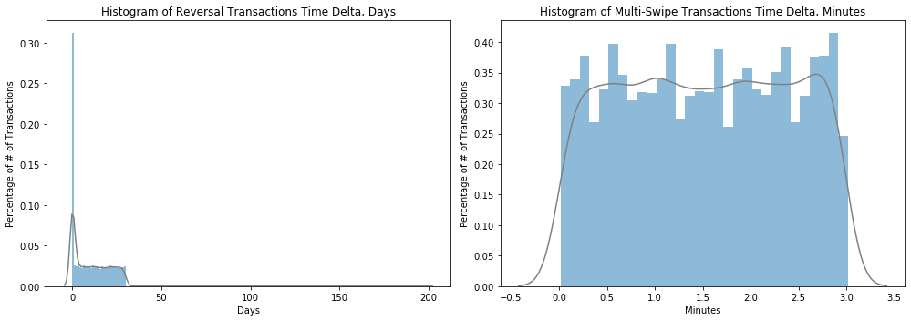

```python
fig = plt.figure(figsize=(14,5))

ax1 = fig.add_subplot(121)
ax2 = fig.add_subplot(122)

sns.histplot(reversal_final['timeDiff'], binwidth=1, stat="density",alpha = 0.5,edgecolor='none', ax=ax1)
sns.kdeplot(reversal_final['timeDiff'], color="gray", ax=ax1)
ax1.set_title('Histogram of Reversal Transactions Time Delta, Days')
ax1.set_xlabel('Days')
ax1.set_ylabel('Percentage of # of Transactions')

sns.histplot(multi_purchase_final['timeDiff'], binwidth=0.1, stat="density", alpha = 0.5,edgecolor='none', ax=ax2)
sns.kdeplot(multi_purchase_final['timeDiff'], color="gray", ax=ax2)
ax2.set_title('Histogram of Multi-Swipe Transactions Time Delta, Minutes')
ax2.set_xlabel('Minutes')
ax2.set_ylabel('Percentage of # of Transactions')

plt.tight_layout()
```

- Generally speaking, the time delta for reversal transactions is longer than the time delta for multi-swipe transactions
- For reversal transactions, over 30% of them happened in one day. Almost all of them happened within 50 days, but the time delta for some reversal transactions could be as long as 197 days.
- For multi-swipe transactions, most of them happen within 3 minutes.

### Histogram of Transaction Amount by isFraud for all, reversal, and multi-swipe transactions

```python
isFraud_True_rev = reversal_final.loc[reversal_final.isFraud_x==True, 'transactionAmount']
isFraud_False_rev = reversal_final.loc[reversal_final.isFraud_x==False, 'transactionAmount']
isFraud_True_multi = multi_purchase_final.loc[multi_purchase_final.isFraud==True, 'transactionAmount']
isFraud_False_multi = multi_purchase_final.loc[multi_purchase_final.isFraud==False, 'transactionAmount']
```

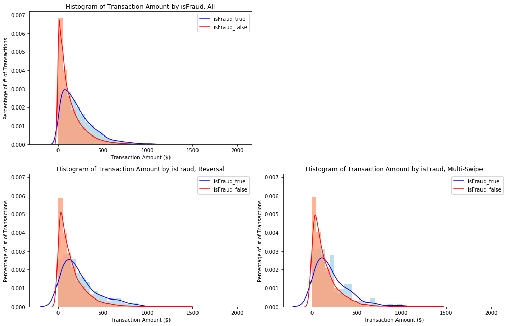

```python
fig = plt.figure(figsize=(14,9))

ax1 = fig.add_subplot(221)
ax2 = fig.add_subplot(223, sharex=ax1, sharey=ax1)
ax3 = fig.add_subplot(224, sharex=ax1, sharey=ax1)

sns.histplot(isFraud_True, binwidth=50, stat="density", color="lightblue", alpha = 0.8,edgecolor='none', ax=ax1)
sns.histplot(isFraud_False, binwidth=50, stat="density", color="lightsalmon", alpha = 0.8,edgecolor='none', ax=ax1)
sns.kdeplot(isFraud_True , color="blue", label="isFraud_true", ax=ax1)
sns.kdeplot(isFraud_False, color="red", label="isFraud_false", ax=ax1)
ax1.set_title('Histogram of Transaction Amount by isFraud, All')
ax1.set_xlabel('Transaction Amount ($)')
ax1.set_ylabel('Percentage of # of Transactions')
ax1.legend()

sns.histplot(isFraud_True_rev, binwidth=50, stat="density", color="lightblue", alpha = 0.8,edgecolor='none', ax=ax2)
sns.histplot(isFraud_False_rev, binwidth=50, stat="density", color="lightsalmon", alpha = 0.8,edgecolor='none', ax=ax2)
sns.kdeplot(isFraud_True_rev , color="blue", label="isFraud_true", ax=ax2)
sns.kdeplot(isFraud_False_rev, color="red", label="isFraud_false", ax=ax2)
ax2.set_title('Histogram of Transaction Amount by isFraud, Reversal')
ax2.set_xlabel('Transaction Amount ($)')
ax2.set_ylabel('Percentage of # of Transactions')
ax2.legend()

sns.histplot(isFraud_True_multi, binwidth=50, stat="density", color="lightblue", alpha = 0.8,edgecolor='none', ax=ax3)
sns.histplot(isFraud_False_multi, binwidth=50, stat="density", color="lightsalmon", alpha = 0.8,edgecolor='none', ax=ax3)
sns.kdeplot(isFraud_True_multi , color="blue", label="isFraud_true", ax=ax3)
sns.kdeplot(isFraud_False_multi, color="red", label="isFraud_false", ax=ax3)
ax3.set_title('Histogram of Transaction Amount by isFraud, Multi-Swipe')
ax3.set_xlabel('Transaction Amount ($)')
ax3.set_ylabel('Percentage of # of Transactions')
ax3.legend()

plt.tight_layout()
```

```python
reversal_final['isFraud_x'].sum()/reversal_final['isFraud_x'].count()
```

```
0.01706465420139671
```

```python
multi_purchase_final['isFraud'].sum()/multi_purchase_final['isFraud'].count()
```

```
0.017317760773258157
```

```python
df['isFraud'].sum()/df['isFraud'].count()
```

```
0.01579041740264992
```

By comparing the histogram of transaction amount by isFraud for all transactions, reversal transactions, and multi-swipe transactions, we generated some insights:

- For all kinds of transaction, the distribution of non-fraud transactions is always more skewed to the right than the distribution of fraud transaction.
- The fraudulent cases in reversal and multi-swipe transactions are less skewed to the right comparing to the distribution of all transactions. For reversal and multi-swipe transactions, there are a certain percentage of transactions with amount from \$500 - \\$1,000.
- Also, the maximum transaction amount in reversal/multi-swipe transactions (~\$1,500) is smaller than the maximum value for all transactions (~\\$2,000).

### Merchant Category Distribution for these duplicates

```python
all_mer = df['merchantCategoryCode'].value_counts(normalize=True).rename_axis('Merchant Category').to_frame('All')
rev_mer = reversal_final['merchantCategoryCode_x'].value_counts(normalize=True).rename_axis('Merchant Category').to_frame('Reversal')
multi_mer = multi_purchase_final['merchantCategoryCode'].value_counts(normalize=True).rename_axis('Merchant Category').to_frame('Multi-Swipe')

all_mer.merge(rev_mer, how='left', on=['Merchant Category']).merge(multi_mer, how='left', on=['Merchant Category']).reset_index()
```

|  | Merchant Category | All | Reversal | Multi-Swipe |
| --- | --- | --- | --- | --- |
| 0 | online_retail | 0.2571 | 0.2758 | 0.2757 |
| 1 | fastfood | 0.1426 | 0.1561 | 0.1600 |
| 2 | entertainment | 0.1019 | 0.1093 | 0.1153 |
| 3 | food | 0.0960 | 0.1055 | 0.1032 |
| 4 | online_gifts | 0.0842 | 0.0928 | 0.0897 |
| 5 | rideshare | 0.0650 | 0.0678 | 0.0685 |
| 6 | hotels | 0.0434 | 0.0501 | 0.0452 |
| 7 | fuel | 0.0304 | nan | nan |
| 8 | subscriptions | 0.0291 | 0.0309 | 0.0311 |
| 9 | auto | 0.0275 | 0.0284 | 0.0271 |
| 10 | health | 0.0243 | 0.0264 | 0.0251 |
| 11 | personal care | 0.0241 | 0.0265 | 0.0278 |
| 12 | airline | 0.0196 | 0.0205 | 0.0230 |
| 13 | mobileapps | 0.0191 | nan | nan |
| 14 | online_subscriptions | 0.0141 | nan | nan |
| 15 | furniture | 0.0095 | 0.0101 | 0.0082 |
| 16 | food_delivery | 0.0076 | nan | nan |
| 17 | gym | 0.0028 | nan | nan |
| 18 | cable/phone | 0.0018 | nan | nan |

- The distribution for Merchant Category is similar for all transactions, reversal transactions, and multi-swipe transactions. Most of the transactions happened with merchant in online retail, fast food, and entertainment category.
- No duplicate transactions happened with fuel merchant while 3% of all transaction is for fuel merchant. It indicates that gas stations are less likely to make multi-swipe transaction or trigger reversal transactions.

# Part 4: ML Model

Fraud is a problem for any bank. Fraud can take many forms, whether it is someone stealing a single credit card, to large batches of stolen credit card numbers being used on the web, or even a mass compromise of credit card numbers stolen from a merchant via tools like credit card skimming devices.

Each of the transactions in the dataset has a field called isFraud. We want to build a predictive model to determine whether a given transaction will be fraudulent or not.

## Data Cleansing

### Missing Values Imputation

From the summary stats above, we know that there are another 5 columns (acqCountry, posEntryMode, merchantCountryCode, transactionType, posConditionCode) with 0.05% - 0.5% missing. We don't have to drop these clolumns since their missing percentages are relatively, but we still need to figure out a way to properly impute these missing values.

Based on the value count distribution, we can see that each one of the 5 variables has a major category that over 40% of the records fall into. Thus, I used the mode value to impute for missing values in these columns.

```python
missing_features = ['acqCountry', 'posEntryMode', 'merchantCountryCode', 'transactionType', 'posConditionCode']
for i in range(len(missing_features)):
    print(df[missing_features[i]].value_counts())
```

```
US     774709
MEX      3130
CAN      2424
PR       1538
Name: acqCountry, dtype: int64
05    315035
09    236481
02    195934
90     19576
80     15283
Name: posEntryMode, dtype: int64
US     778511
MEX      3143
CAN      2426
PR       1559
Name: merchantCountryCode, dtype: int64
PURCHASE                745193
REVERSAL                 20303
ADDRESS_VERIFICATION     20169
Name: transactionType, dtype: int64
01    628787
08    149634
99      7533
Name: posConditionCode, dtype: int64
```

```python
for i in range(len(missing_features)):
    df[missing_features[i]] = df[missing_features[i]].fillna(df[missing_features[i]].mode()[0])
```

## More features

### Duplicates (Reversal or Multi-Swipe)

Based on the discussion in part 3, duplicate transactions are pretty suspicious and are more likely to be fraud. Therefore, I have added 2 features here to identify the duplicates for reversal and multi-swipe transactions:

- **Reversal:** 1 for reversal, 0 for non-reversal
- **Multi:** 1 for multi-swipe, 0 for non multi-swipe

```python
df_new = pd.merge(df, reversal_final[['transactionKey_x','Match']], left_on = 'transactionKey', right_on = 'transactionKey_x', how = 'left').merge(multi_purchase_final[['transactionKey','Multi']], on = 'transactionKey', how = 'left')
df_new.drop('transactionKey_x', axis=1, inplace=True)
df_new.loc[df_new['Match'] != 1, 'Match'] = 0
df_new.loc[df_new['Multi'] != 1, 'Multi'] = 0
#df_new.loc[df_new['Multi_T'] != 1, 'Multi_T'] = 0
df_new.rename(columns={'Match': 'Reversal'},inplace=True)
```

### matchCVV

CVV (Card verification value) is a three- or four-digit number on the card that adds an extra layer of security for the credit card. If the CVV is entered incorrectly when making transactions, it is more likely that the transaction is fraud.

The original data set haves 2 columns related to CVV: `cardCVV` and `enteredCVV`. I created a new feature named `matchCVV` to check whether the CVV is entered correctly for each transaction.

- **matchCVV**: 1 if cardCVV = enteredCVV, otherwise 0

```python
df_new['matchCVV'] = (df_new['cardCVV'] == df_new['enteredCVV']).astype(int)
df_new = df_new.drop(['cardCVV', 'enteredCVV'], axis=1)
```

### matchCountry

In most cases, the transaction should be made in the same country as the country that the customer acquired the card. It is more likely to be a fraudulent case if the transaction is made in another country.

The original data set haves 2 columns: `acqCountry` and `merchantCountryCode`. I created a new feature named `matchCountry` to check whether the `acqCountry` matches with the `merchantCountryCode`.

- **matchCountry:** 1 if acqCountry = merchantCountryCode, otherwise 0

```python
df_new['matchCountry'] = (df_new['acqCountry'] == df_new['merchantCountryCode']).astype(int)
df_new = df_new.drop(['acqCountry', 'merchantCountryCode'], axis=1)
```

### newMerchant

The `merchantName` column has too many unique values. If we do one-hot encoding on it, we may face the issue of curse of dimentionality. To solve this, I converted it to a new feature named `newMerchant` to identify whether the transaction is the first time that the customer has interacted with the merchant. If the transaction is made in a merchant that the customer has never shopped with, it has higher possibility that the transaction is a fraud.

- **newMerchant:** 1 if the transaction is the first time that the customer has interacted with the merchant, otherwise 0

We can further improve this feature if we are able to get more historical transaction data. The data we have now is limited since it is only for year 2016.

```python
df_new = df_new.sort_values(['customerId', 'merchantName', 'transactionDateTime'])
df_new['cnt'] = df_new.groupby(['customerId', 'merchantName']).cumcount()
df_new.loc[df_new['cnt'] == 0, 'newMerchant'] = 1
df_new.loc[df_new['cnt'] > 0, 'newMerchant'] = 0
df_new = df_new.drop(['merchantName', 'cnt'], axis=1)
```

### Dates

- **daysSinceaccountOpen:** # of days since account opened
- **daysSinceLastAddressChange:** # of days since last address change
- **daysTillExpDate:** # of days till card expiration date
- **transactionWeekday:** weekday of the transaction time
- **transactionHour:** hour of the transaction time
- **transactionDay:** day of the transaction time
- **transactionMonth:** month of the transaction time

```python
df_new['daysSinceaccountOpen'] = (df_new['transactionDateTime'] - df_new['accountOpenDate']).dt.days
df_new['daysSinceLastAddressChange'] = (df_new['transactionDateTime'] - df_new['dateOfLastAddressChange']).dt.days
df_new['daysTillExpDate'] = (df_new['currentExpDate'] - df_new['transactionDateTime']).dt.days
df_new['transactionWeekday'] = df_new['transactionDateTime'].dt.weekday
df_new['transactionHour'] = df_new['transactionDateTime'].dt.hour
df_new['transactionDay'] = df_new['transactionDateTime'].dt.day
df_new['transactionMonth'] = df_new['transactionDateTime'].dt.month
df_new = df_new.drop(['transactionDateTime', 'accountOpenDate', 'dateOfLastAddressChange', 'currentExpDate'], axis=1)
```

## Feature Selection

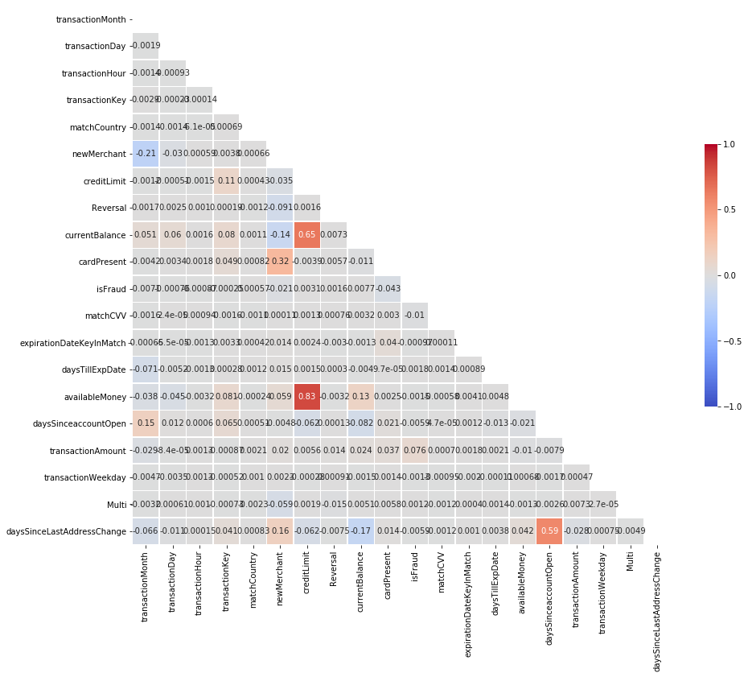

```python
corr_features = list(set(df_new.columns))
corr_matrix = df_new[corr_features].corr()

# Set Up Mask To Hide Upper Triangle
mask = np.zeros_like(corr_matrix, dtype=np.bool)
mask[np.triu_indices_from(mask)]= True

# Create Heatmap in Seaborn
f, ax = plt.subplots(figsize=(15, 15))
heatmap = sns.heatmap(corr_matrix,
                      mask = mask,
                      square = True,
                      linewidths = .5,
                      annot=True,
                      cmap = 'coolwarm',
                      cbar_kws = {'shrink': .4,
                                'ticks' : [-1, -.5, 0, 0.5, 1]},
                      vmin = -1,
                      vmax = 1)
#add the column names as labels
ax.set_yticklabels(corr_matrix.columns, rotation = 0)
ax.set_xticklabels(corr_matrix.columns)
sns.set_style({'xtick.bottom': True}, {'ytick.left': True})
```

Based on the correlation plot above, we can learn that:

```python
df_new.head()
```

|  | customerId | creditLimit | availableMoney | transactionAmount | posEntryMode | posConditionCode | merchantCategoryCode | cardLast4Digits | transactionType | currentBalance | cardPresent | expirationDateKeyInMatch | isFraud | transactionKey | Reversal | Multi | matchCVV | matchCountry | newMerchant | daysSinceaccountOpen | daysSinceLastAddressChange | daysTillExpDate | transactionWeekday | transactionHour | transactionDay | transactionMonth |
| --- | --- | --- | --- | --- | --- | --- | --- | --- | --- | --- | --- | --- | --- | --- | --- | --- | --- | --- | --- | --- | --- | --- | --- | --- | --- | --- |
| 541917 | 100088067 | 50000 | 49953.8100 | 200.1200 | 09 | 01 | food | 4615 | PURCHASE | 46.1900 | True | False | False | 541917 | 0.0000 | 0.0000 | 1 | 1 | 1.0000 | 820 | 820 | 4831 | 4 | 19 | 8 | 4 |
| 541962 | 100088067 | 50000 | 49929.3100 | 95.1100 | 02 | 01 | food | 2077 | PURCHASE | 70.6900 | True | False | False | 541962 | 0.0000 | 0.0000 | 1 | 1 | 1.0000 | 1035 | 1035 | 1603 | 2 | 7 | 9 | 11 |
| 541920 | 100088067 | 50000 | 49996.0400 | 5.2600 | 02 | 01 | food | 4615 | PURCHASE | 3.9600 | True | False | False | 541920 | 0.0000 | 0.0000 | 1 | 1 | 1.0000 | 848 | 848 | 6264 | 4 | 2 | 6 | 5 |
| 541904 | 100088067 | 50000 | 49933.9300 | 141.6000 | 09 | 08 | food | 4615 | PURCHASE | 66.0700 | True | False | False | 541904 | 0.0000 | 0.0000 | 1 | 1 | 1.0000 | 755 | 755 | 5384 | 2 | 4 | 3 | 2 |
| 541925 | 100088067 | 50000 | 50000.0000 | 304.1500 | 02 | 01 | entertainment | 4615 | PURCHASE | 0.0000 | True | False | False | 541925 | 0.0000 | 0.0000 | 1 | 1 | 1.0000 | 876 | 876 | 5994 | 4 | 18 | 3 | 6 |

## Data Transformation

Here are the steps I took:

- Step 1: Drop columns with too many unique values and columns that need to be dropped based on the analysis on correlation plot.
- Step 2: Make sure all columns have the desired data types
- Step 3: Data Transformation
  - Categorical Variables: One-Hot Encoding
  - Boolean Variables: Convert to integer (0 or 1)
  - Numerical Variables: Keep the same

```python
# Drop columns with too many unique values and with high correlation with other features
df_new = df_new.drop(['daysSinceLastAddressChange', 'availableMoney', 'customerId', 'cardLast4Digits', 'transactionKey'], axis=1)
```

```python
# Convert Data Type
#df_new['transaction_month'] = df_new['transaction_month'].astype('object')
df_new['Reversal'] = df_new['Reversal'].astype('int')
df_new['Multi'] = df_new['Multi'].astype('int')
```

```python
# One-Hot Encoding for Categorical Variables
cat_col = df_new.select_dtypes(include=['object']).columns.to_list()
dummy_df = pd.get_dummies(df_new[cat_col],drop_first=True)
df_new = pd.concat([df_new, dummy_df], axis=1)
df_new = df_new.drop(cat_col, axis=1)
```

```python
# Convert boolean features into interger
boo_col = df_new.select_dtypes(include=['bool']).columns.to_list()
for column in boo_col:
    df_new[column] = df_new[column].astype(int)
```

```python
df_final = df_new.copy()
df_final.shape
```

```
(786363, 43)
```

## Data Split

To get a similar distribution for both training set and test set, we stratified the dataset based on the target variable.

There are **786,363** records in total. We used a 80:20 split here. **629,090** is split into the training and **157,273** is in the test set.

```python
# Partition the data
X_features = list(set(df_final.columns) - set(['isFraud']))
X = df_final[X_features]
y = df_final['isFraud']

X_train, X_test, y_train, y_test = train_test_split(X, y, train_size=0.8, stratify=y, random_state = RANDOMSTATE)
print ('Train Features: ',X_train.shape ,
      'Test Features: ',X_test.shape)
print ('Train Labels: ',y_train.shape ,
      'Test Labels: ',y_test.shape)
```

```
Train Features:  (629090, 42) Test Features:  (157273, 42)
Train Labels:  (629090,) Test Labels:  (157273,)
```

## SMOTE (Balance the Data)

In the original dataset, the class within the dependent variable `isFraud` is pretty imbalanced. Fraud cases are much less than non-fraud ones. In order to balance the dataset and improve model performance, I used the `SMOTE()` function to oversample the data.

`SMOTE()` function generates synthetic samples for the minority class by randomly selecting one or more of the k-nearest neighbors for each example in the minority class. Before this oversampling process, we have 1.58% fraud the data is reconstructed and balanced.

```python
# SMOTE
n_sample = y_train.shape[0]
n_pos_sample = y_train[y_train == 0].shape[0]
n_neg_sample = y_train[y_train == 1].shape[0]
print('Observations: {}; non-Frauds: {:.2%}; Frauds: {:.2%}'.format(n_sample,
                                                   n_pos_sample / n_sample,
                                                   n_neg_sample / n_sample))
print('Features: ', X_train.shape[1])
```

```
Observations: 629090; non-Frauds: 98.42%; Frauds: 1.58%
Features:  42
```

```python
sm = SMOTE(random_state=RANDOMSTATE)
X_train, y_train = sm.fit_resample(X_train, y_train)
print('After SMOTE: ')
n_sample = y_train.shape[0]
n_pos_sample = y_train[y_train == 0].shape[0]
n_neg_sample = y_train[y_train == 1].shape[0]
print('Observations: {}; non-Frauds: {:.2%}; Frauds: {:.2%}'.format(n_sample,
                                                   n_pos_sample / n_sample,
                                                   n_neg_sample / n_sample))
```

```
After SMOTE:
Observations: 1238312; non-Frauds: 50.00%; Frauds: 50.00%
```

## Modeling

### Define Evaluation Metrics

We need to be careful about the model evalutaion metrics as we are dealing with imbalanced data. Prioritizing precision or recall is important in such cases and must be evaluated based on use case. Below are the metrics I have designed in the model evaluation function:

- **Accuracy** is the most common performance metric used for classification algorithms. Accuracy is mainly used for a balanced dataset. It is defined as the ratio of the number of correct predictions made to all the predictions made. Note that it may not work well with unbalanced datasets as it may get biased towards the majority class.
- **ROC-AUC** is a typical evaluation metric for model performance. However, it can sometimes be misleading in some very imbalanced applications (just as our case). A ROC curve can still look pretty good (ie better than random) while misclassifying most or all of the minority class.
- **Precision** is an importance evaluation metric. It indicates that from all the points predicted to positive how many of them are actually positive.
- **Recall** is also an influential evaluation metric. Under the same model performance, recall could suggest how much percentage of real frauds have our models captured, which also tightly connect to our business goal. It supports finding the optimal threshold.
- **PR-Curve** could help to find a balanced point of the threshold between recall and precision, where marginal increase of recall shows down in PR-curve. It is specifically tailored for the detection of rare events and are pretty useful in those scenarios. They will show that your classifier has a low performance if it is misclassifying most or all of the minority class.
- **F1 Score**, which is the harmonic mean of precision and recall, can give us a more comprehensive understanding of the model.

If we have more time, we could also consider dividing data into multiple deciles and ploting the Lift Chart to further evaluate model performance.

Reference: [The Relationship Between Precision-Recall and ROC Curves](http://pages.cs.wisc.edu/~jdavis/davisgoadrichcamera2.pdf)

```python
def roc_plot(model, X_train, X_test, y_train, y_test):
    probas_0 = model.predict_proba(X_train)[:,1]
    probas_1 = model.predict_proba(X_test)[:,1]

    #if (model == lr) or (model == cls):
    #    probas_0 = model.predict_proba(X_train)[:,1]
    #    probas_1 = model.predict_proba(X_test)[:,1]
    #else:
    #    probas_0 = model.predict(dtrain, ntree_limit=model.best_iteration)
    #    probas_1 = model.predict(dtest, ntree_limit=model.best_iteration)

    fpr_0, tpr_0, thresholds_0 = roc_curve(y_train, probas_0)
    fpr_1, tpr_1, thresholds_1 = roc_curve(y_test, probas_1)
    roc_auc_0 = auc(fpr_0, tpr_0)
    roc_auc_1 = auc(fpr_1, tpr_1)
    print("Area under the ROC curve - train: %f" % roc_auc_0)
    print("Area under the ROC curve - test: %f" % roc_auc_1)
    # Plot ROC curve
    plt.figure(figsize=(8,6))
    plt.plot(fpr_0, tpr_0, label='ROC curve - train(AUC = %0.2f)' % roc_auc_0, color='r')
    plt.plot(fpr_1, tpr_1, label='ROC curve - test (AUC = %0.2f)' % roc_auc_1, color='b')
    plt.plot([0, 1], [0, 1], 'k--')
    plt.xlim([0.0, 1.0])
    plt.ylim([0.0, 1.0])
    plt.xlabel('False Positive Rate')
    plt.ylabel('True Positive Rate')
    plt.title('ROC Curve')
    plt.legend(loc="lower right")
    plt.show()
```

```python
def model_eval(model, X_train, X_test, y_train, y_test, threshold=0.5):
    y_prob = model.predict_proba(X_test)[:,1]
    # The first column is the probability of the predicted output being zero, that is 1 - 𝑝(𝑥).
    # The second column is the probability that the output is one, or 𝑝(𝑥).
    #y_pred_default = model.predict(X_test)
    y_pred = (y_prob >= threshold).astype('bool')

    print("Accuracy:", metrics.accuracy_score(y_test, y_pred))
    print("Precision:", metrics.precision_score(y_test, y_pred))
    print("Recall:", metrics.recall_score(y_test, y_pred))
    print("F1 Score:", metrics.f1_score(y_test, y_pred))

    print('*********************************************************************************')
    #confusion_matrix
    cnf_matrix = metrics.confusion_matrix(y_test, y_pred)
    print("Confusion Matrix:")
    print(cnf_matrix)

    print('*********************************************************************************')
    #roc_curve
    roc_plot(model, X_train, X_test, y_train, y_test)
```

### Baseline Model: Logistic Model

Before we start to explore more advanced algorithms, I would like to first create a baseline model to get a sense of model performance. The baseline model should be a simple one. Since this is a classification problem and the outcome variable is either 0 or 1, I went with the Lgistic Regression Model here.

```python
# Normalize the data
sc = StandardScaler()
X_train_s = sc.fit_transform(X_train)
X_test_s = sc.transform(X_test)
```

```python
lr = LogisticRegression(solver='liblinear', penalty = 'l2', random_state=RANDOMSTATE, max_iter = 200)
lrr = lr.fit(X_train_s, y_train)
```

```
Accuracy: 0.8939423804467391
Precision: 0.03878890260541875
Recall: 0.24043495771244464
F1 Score: 0.06680093991272239
Confusion Matrix:
[[139996  14794]
 [  1886    597]]
Area under the ROC curve - train: 0.984503
Area under the ROC curve - test: 0.680827
```

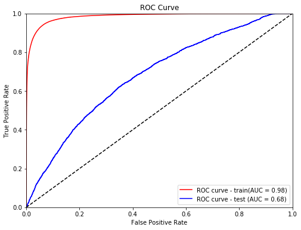

```python
model_eval(lr, X_train_s, X_test_s, y_train, y_test)
```

We know that the default threshold/cut-off value for classification model is 0.5. I would like to do some more investigations here to find the best cut-off value and thus improve the model performance.

I used a for-loop scan here to iterate through different combination of threhold, regularization strength, and solver & penalty to see which combination can provide the best performance.

```python
threshold = [0.05, 0.1, 0.15, 0.2, 0.25]
C = [500, 1000]
penalty = [['saga','l2'], ['saga','none'], ['lbfgs','l2'], ['liblinear','l2'], ['lbfgs','none'],['liblinear','l1']]
result = pd.DataFrame(columns = ['C', 'penalty', 'solver','threshold', 'accuracy', 'precision', 'recall', 'auc', 'ap'])
```

```python
%%time
for i in C:
    for j in range(len(penalty)):
        lr = LogisticRegression(solver= penalty[j][0], penalty = penalty[j][1], C = i, random_state=RANDOMSTATE, max_iter = 200)
        lr.fit(X_train_s, y_train)
        for t in threshold:
            y_prob = lr.predict_proba(X_test_s)[:,1]
            y_pred = (y_prob >= t).astype('bool')

            accuracy_score = metrics.accuracy_score(y_test, y_pred)
            precision_score = metrics.precision_score(y_test, y_pred)
            recall_score = metrics.recall_score(y_test, y_pred)
            average_precision = metrics.average_precision_score(y_test, y_prob)
            auc_score = metrics.roc_auc_score(y_test, y_prob)

            temp = pd.DataFrame([[i, penalty[j][1], penalty[j][0], t, accuracy_score, precision_score, recall_score, auc_score, average_precision]],columns = ['C', 'penalty', 'solver','threshold', 'accuracy', 'precision', 'recall', 'auc', 'ap'])
            result = result.append(temp)
```

```
Wall time: 19min 57s
```

```python
result
```

|  | C | penalty | solver | threshold | accuracy | precision | recall | auc | ap |
| --- | --- | --- | --- | --- | --- | --- | --- | --- | --- |
| 0 | 500 | l2 | saga | 0.0500 | 0.4697 | 0.0227 | 0.7757 | 0.6809 | 0.0317 |
| 0 | 500 | l2 | saga | 0.1000 | 0.6111 | 0.0263 | 0.6549 | 0.6809 | 0.0317 |
| 0 | 500 | l2 | saga | 0.1500 | 0.6899 | 0.0288 | 0.5699 | 0.6809 | 0.0317 |
| 0 | 500 | l2 | saga | 0.2000 | 0.7371 | 0.0308 | 0.5143 | 0.6809 | 0.0317 |
| 0 | 500 | l2 | saga | 0.2500 | 0.7763 | 0.0328 | 0.4615 | 0.6809 | 0.0317 |
| 0 | 500 | none | saga | 0.0500 | 0.4697 | 0.0227 | 0.7757 | 0.6809 | 0.0317 |
| 0 | 500 | none | saga | 0.1000 | 0.6111 | 0.0263 | 0.6549 | 0.6809 | 0.0317 |
| 0 | 500 | none | saga | 0.1500 | 0.6899 | 0.0288 | 0.5699 | 0.6809 | 0.0317 |
| 0 | 500 | none | saga | 0.2000 | 0.7371 | 0.0308 | 0.5143 | 0.6809 | 0.0317 |
| 0 | 500 | none | saga | 0.2500 | 0.7763 | 0.0328 | 0.4615 | 0.6809 | 0.0317 |
| 0 | 500 | l2 | lbfgs | 0.0500 | 0.4697 | 0.0227 | 0.7757 | 0.6809 | 0.0317 |
| 0 | 500 | l2 | lbfgs | 0.1000 | 0.6111 | 0.0263 | 0.6549 | 0.6809 | 0.0317 |
| 0 | 500 | l2 | lbfgs | 0.1500 | 0.6899 | 0.0288 | 0.5699 | 0.6809 | 0.0317 |
| 0 | 500 | l2 | lbfgs | 0.2000 | 0.7371 | 0.0308 | 0.5143 | 0.6809 | 0.0317 |
| 0 | 500 | l2 | lbfgs | 0.2500 | 0.7763 | 0.0328 | 0.4615 | 0.6809 | 0.0317 |
| 0 | 500 | l2 | liblinear | 0.0500 | 0.4697 | 0.0227 | 0.7757 | 0.6808 | 0.0317 |
| 0 | 500 | l2 | liblinear | 0.1000 | 0.6111 | 0.0263 | 0.6549 | 0.6808 | 0.0317 |
| 0 | 500 | l2 | liblinear | 0.1500 | 0.6899 | 0.0288 | 0.5699 | 0.6808 | 0.0317 |
| 0 | 500 | l2 | liblinear | 0.2000 | 0.7371 | 0.0308 | 0.5143 | 0.6808 | 0.0317 |
| 0 | 500 | l2 | liblinear | 0.2500 | 0.7763 | 0.0328 | 0.4615 | 0.6808 | 0.0317 |
| 0 | 500 | none | lbfgs | 0.0500 | 0.4697 | 0.0227 | 0.7757 | 0.6809 | 0.0317 |
| 0 | 500 | none | lbfgs | 0.1000 | 0.6111 | 0.0263 | 0.6549 | 0.6809 | 0.0317 |
| 0 | 500 | none | lbfgs | 0.1500 | 0.6899 | 0.0288 | 0.5699 | 0.6809 | 0.0317 |
| 0 | 500 | none | lbfgs | 0.2000 | 0.7370 | 0.0308 | 0.5143 | 0.6809 | 0.0317 |
| 0 | 500 | none | lbfgs | 0.2500 | 0.7763 | 0.0328 | 0.4615 | 0.6809 | 0.0317 |
| 0 | 500 | l1 | liblinear | 0.0500 | 0.4696 | 0.0227 | 0.7761 | 0.6808 | 0.0317 |
| 0 | 500 | l1 | liblinear | 0.1000 | 0.6110 | 0.0262 | 0.6549 | 0.6808 | 0.0317 |
| 0 | 500 | l1 | liblinear | 0.1500 | 0.6897 | 0.0288 | 0.5699 | 0.6808 | 0.0317 |
| 0 | 500 | l1 | liblinear | 0.2000 | 0.7370 | 0.0308 | 0.5143 | 0.6808 | 0.0317 |
| 0 | 500 | l1 | liblinear | 0.2500 | 0.7762 | 0.0327 | 0.4615 | 0.6808 | 0.0317 |
| 0 | 1000 | l2 | saga | 0.0500 | 0.4697 | 0.0227 | 0.7757 | 0.6809 | 0.0317 |
| 0 | 1000 | l2 | saga | 0.1000 | 0.6111 | 0.0263 | 0.6549 | 0.6809 | 0.0317 |
| 0 | 1000 | l2 | saga | 0.1500 | 0.6899 | 0.0288 | 0.5699 | 0.6809 | 0.0317 |
| 0 | 1000 | l2 | saga | 0.2000 | 0.7371 | 0.0308 | 0.5143 | 0.6809 | 0.0317 |
| 0 | 1000 | l2 | saga | 0.2500 | 0.7763 | 0.0328 | 0.4615 | 0.6809 | 0.0317 |
| 0 | 1000 | none | saga | 0.0500 | 0.4697 | 0.0227 | 0.7757 | 0.6809 | 0.0317 |
| 0 | 1000 | none | saga | 0.1000 | 0.6111 | 0.0263 | 0.6549 | 0.6809 | 0.0317 |
| 0 | 1000 | none | saga | 0.1500 | 0.6899 | 0.0288 | 0.5699 | 0.6809 | 0.0317 |
| 0 | 1000 | none | saga | 0.2000 | 0.7371 | 0.0308 | 0.5143 | 0.6809 | 0.0317 |
| 0 | 1000 | none | saga | 0.2500 | 0.7763 | 0.0328 | 0.4615 | 0.6809 | 0.0317 |
| 0 | 1000 | l2 | lbfgs | 0.0500 | 0.4697 | 0.0227 | 0.7757 | 0.6809 | 0.0317 |
| 0 | 1000 | l2 | lbfgs | 0.1000 | 0.6111 | 0.0263 | 0.6549 | 0.6809 | 0.0317 |
| 0 | 1000 | l2 | lbfgs | 0.1500 | 0.6899 | 0.0288 | 0.5699 | 0.6809 | 0.0317 |
| 0 | 1000 | l2 | lbfgs | 0.2000 | 0.7371 | 0.0308 | 0.5143 | 0.6809 | 0.0317 |
| 0 | 1000 | l2 | lbfgs | 0.2500 | 0.7763 | 0.0328 | 0.4615 | 0.6809 | 0.0317 |
| 0 | 1000 | l2 | liblinear | 0.0500 | 0.4697 | 0.0227 | 0.7757 | 0.6808 | 0.0317 |
| 0 | 1000 | l2 | liblinear | 0.1000 | 0.6111 | 0.0263 | 0.6549 | 0.6808 | 0.0317 |
| 0 | 1000 | l2 | liblinear | 0.1500 | 0.6899 | 0.0288 | 0.5699 | 0.6808 | 0.0317 |
| 0 | 1000 | l2 | liblinear | 0.2000 | 0.7371 | 0.0308 | 0.5143 | 0.6808 | 0.0317 |
| 0 | 1000 | l2 | liblinear | 0.2500 | 0.7763 | 0.0328 | 0.4615 | 0.6808 | 0.0317 |
| 0 | 1000 | none | lbfgs | 0.0500 | 0.4697 | 0.0227 | 0.7757 | 0.6809 | 0.0317 |
| 0 | 1000 | none | lbfgs | 0.1000 | 0.6111 | 0.0263 | 0.6549 | 0.6809 | 0.0317 |
| 0 | 1000 | none | lbfgs | 0.1500 | 0.6899 | 0.0288 | 0.5699 | 0.6809 | 0.0317 |
| 0 | 1000 | none | lbfgs | 0.2000 | 0.7370 | 0.0308 | 0.5143 | 0.6809 | 0.0317 |
| 0 | 1000 | none | lbfgs | 0.2500 | 0.7763 | 0.0328 | 0.4615 | 0.6809 | 0.0317 |
| 0 | 1000 | l1 | liblinear | 0.0500 | 0.4696 | 0.0227 | 0.7761 | 0.6808 | 0.0317 |
| 0 | 1000 | l1 | liblinear | 0.1000 | 0.6110 | 0.0262 | 0.6549 | 0.6808 | 0.0317 |
| 0 | 1000 | l1 | liblinear | 0.1500 | 0.6897 | 0.0288 | 0.5699 | 0.6808 | 0.0317 |
| 0 | 1000 | l1 | liblinear | 0.2000 | 0.7370 | 0.0308 | 0.5143 | 0.6808 | 0.0317 |
| 0 | 1000 | l1 | liblinear | 0.2500 | 0.7762 | 0.0327 | 0.4615 | 0.6808 | 0.0317 |

```python
def optimal_cutoff(model, X_test, y_test):
    probas_1 = model.predict_proba(X_test)[:,1]
    fpr_1, tpr_1, thresholds_1 = roc_curve(y_test, probas_1)
    y = tpr_1 - fpr_1
    youden_index = np.argmax(y)
    optimal_cutoff = thresholds_1[youden_index]
    point = [fpr_1[youden_index], tpr_1[youden_index]]
    return optimal_cutoff, point

optimal_cutoff(lr, X_test_s, y_test)
```

```
(0.11386768751260574, [0.3609535499709284, 0.6335078534031413])
```

```
Accuracy: 0.6387809732121852
Precision: 0.027369373444921963
Recall: 0.6335078534031413
F1 Score: 0.05247181266261926
Confusion Matrix:
[[98890 55900]
 [  910  1573]]
Area under the ROC curve - train: 0.984503
Area under the ROC curve - test: 0.680827
```

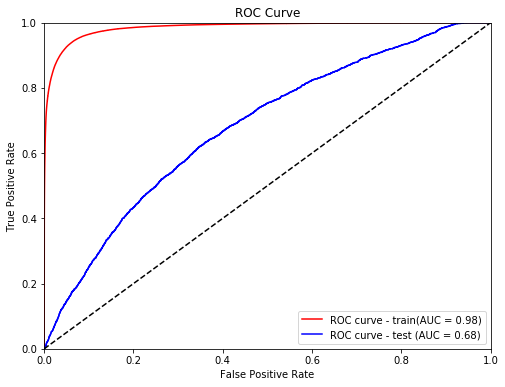

```python
model_eval(lr, X_train_s, X_test_s, y_train, y_test, 0.1138)
```

As we are dealing with fraud detection problem, I think that we need to focus more on the recall value to capture as many fruads as possible. We can see that threshold = 0.1 will lead to better results (recall) under the same model performance (The AUC and Average Precision would not change).

Also, we checked the Youden Index and decided to set the optimal cut-off as 0.1138.

We also notice that the AUC for training set is as high as 0.98 while the AUC for test set is only 0.68. It indicates that our model might have over-fitting issue.

### XGBoost

After building the baseline model, we've gained better understanding on the data. Now, we want to try the xgboost model. It is an optimized distributed gradient boosting library that has been used with great success on many machine learning challenges.

```python
# First manually define parameters
params = {"objective": "binary:logistic",
          "eval_metric": "logloss",
          "learning_rate": 0.05,
          "max_depth": 5,
          "subsample": 0.8,
          "colsample_bytree": 0.8,
          "scale_pos_weight": len(y_train[y_train == 0])/len(y_train[y_train == 1]),
          "seed": 101,
          "gamma": 0.1,
          "min_child_weight": 10,
          "lambda": 10}
```

```python
%%time

cls = XGBClassifier(
    random_state=RANDOMSTATE,
    use_label_encoder=False,
    n_jobs=-1,
    **params
)

# set early_stopping_rounds = 10 to avoid overfitting
cls.fit(X_train_s, y_train, early_stopping_rounds=10,eval_set=[(X_test_s, y_test)], verbose=False)
```

```
Wall time: 2min 7s
```

[output not shown]

```
Accuracy: 0.4660176889866665
Precision: 0.02294598328221218
Recall: 0.7893677003624647
F1 Score: 0.0445956246231556
Confusion Matrix:
[[71332 83458]
 [  523  1960]]
Area under the ROC curve - train: 0.966371
Area under the ROC curve - test: 0.689703
```

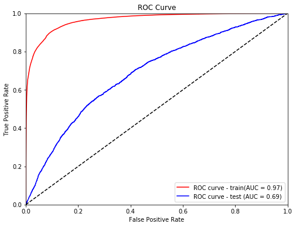

```python
# Create model evaluation report; set the cut-off threshold to 0.1138
model_eval(cls, X_train_s, X_test_s, y_train, y_test, 0.1138)
```

## Hyperparameter Tuning (Bayesian Optimization)

In order to further improve the XGBoost model performance, we used the bayesian optimization for hyperparameter tuning.

The reason why we chose Bayesian optimization methods instead of grid search and random search is that Bayesian optimization methods are more efficient. With Bayesian optimization, hyperparameters are selected in an informed manner. It would prioritize hyperparameters that appear to be more promising from past results and find the best hyperparameters in fewer iterations and shorter period of time than both grid search and random search.

Reference: [XGBoost and Random Forest with Bayesian Optimisation](http://www.thetalkingmachines.com/article/xgboost-and-random-forest-bayesian-optimisation-1)

```python
#Bayesian optimization
def bayesian_optimization(dataset, function, parameters):
   X_train, y_train, X_test, y_test = dataset
   n_iterations = 5
   gp_params = {"alpha": 1e-4}

   BO = BayesianOptimization(function, parameters)
   BO.maximize(n_iter=n_iterations, **gp_params)

   return BO, BO.max
```

```python
def xgb_optimization(X1, y1, cv_splits, eval_set):
    def function(eta, max_depth, min_child_weight, colsample_bytree, subsample, gamma):
            return cross_val_score(
                   XGBClassifier(
                   objective="binary:logistic",
                   random_state = RANDOMSTATE,
                   reg_lambda=10,
                   learning_rate=max(eta, 0),
                   max_depth=int(max_depth),
                   subsample=max(subsample, 0),
                   colsample_bytree=max(colsample_bytree, 0),
                   scale_pos_weight = len(y_train[y_train == 0])/
                                      len(y_train[y_train == 1]),
                   seed=101,
                   gamma=max(gamma, 0),
                   min_child_weight=int(min_child_weight)),
                   X=X1,
                   y=y1,
                   cv=cv_splits,
                   #scoring="f1",
                   fit_params={
                        "early_stopping_rounds": 10,
                        "eval_metric": "logloss",
                        "eval_set": eval_set},
                   n_jobs=-1).mean()

    parameters = {'eta': (0.01, 0.4),
                  'max_depth': (3, 6),
                  'min_child_weight': (10, 30),
                  'colsample_bytree': (0.2, 0.8),
                  'subsample': (0.5, 1),
                  'gamma': (0, 2)}


    return function, parameters
```

```python
dataset = (X_train_s, y_train, X_test_s, y_test)
cv_splits = 4
eval_set = [(X_test_s, y_test)]

best_solution = bayesian_optimization(dataset, *xgb_optimization(X_train_s, y_train, cv_splits, eval_set))
best_solution
```

```
|   iter    |  target   | colsam... |    eta    |   gamma   | max_depth | min_ch... | subsample |
-------------------------------------------------------------------------------------------------
|  1        |  0.9305   |  0.3481   |  0.1599   |  1.397    |  5.736    |  17.86    |  0.8477   |
|  2        |  0.9145   |  0.3123   |  0.08856  |  0.1961   |  4.516    |  13.12    |  0.6922   |
|  3        |  0.8998   |  0.5539   |  0.05665  |  0.9325   |  4.761    |  25.16    |  0.5362   |
|  4        |  0.8778   |  0.3307   |  0.04371  |  1.861    |  3.013    |  18.98    |  0.7171   |
|  5        |  0.9187   |  0.3509   |  0.1694   |  1.018    |  3.695    |  28.14    |  0.9629   |
|  6        |  0.9308   |  0.5419   |  0.1493   |  0.2252   |  5.496    |  10.0     |  0.9364   |
|  7        |  0.9388   |  0.4742   |  0.3613   |  0.04142  |  5.994    |  29.97    |  0.6911   |
|  8        |  0.9383   |  0.2      |  0.3944   |  2.0      |  6.0      |  29.85    |  0.9997   |
|  9        |  0.8982   |  0.691    |  0.03835  |  1.917    |  5.971    |  10.0     |  0.5467   |
|  10       |  0.9376   |  0.4446   |  0.3174   |  0.02705  |  5.766    |  29.68    |  0.9764   |
=================================================================================================
```

```
(<bayes_opt.bayesian_optimization.BayesianOptimization at 0x14345e501c8>,
 {'target': 0.9387989773029168,
  'params': {'colsample_bytree': 0.4742093127592237,
   'eta': 0.3613297365752704,
   'gamma': 0.04142458507341962,
   'max_depth': 5.993976091885929,
   'min_child_weight': 29.966576900827068,
   'subsample': 0.6911221988105496}})
```

Great work! Bayesian Optimization Methods have helped us found the best hyperparameters at the 7th iteration. Let's plug them in to the model and see how the model performance would be.

```python
# Plug in the best hyperparameters to our model
params = best_solution[1]["params"]

params_final = {"objective": "binary:logistic",
          "eval_metric": "logloss",
          "lambda": 10,
          "learning_rate": max(params["eta"],0.01),
          "max_depth": int(max(params["max_depth"],3)),
          "subsample": max(params["subsample"],0.5),
          "colsample_bytree": max(params["colsample_bytree"],0.2),
          "scale_pos_weight": len(y_train[y_train == 0])/len(y_train[y_train == 1]),
          "seed": 101,
          "gamma": max(params["gamma"],0),
          "min_child_weight": int(max(params["min_child_weight"],10))}
```

```python
cls_final = XGBClassifier(
    random_state=RANDOMSTATE,
    use_label_encoder=False,
    **params_final
)

cls_final.fit(X_train_s, y_train, early_stopping_rounds=10,eval_set=[(X_test_s, y_test)], verbose=False)
```

```
XGBClassifier(base_score=0.5, booster='gbtree', colsample_bylevel=1,
              colsample_bynode=1, colsample_bytree=0.4742093127592237,
              eval_metric='logloss', gamma=0.04142458507341962, gpu_id=-1,
              importance_type='gain', interaction_constraints='', lambda=10,
              learning_rate=0.3613297365752704, max_delta_step=0, max_depth=5,
              min_child_weight=29, missing=nan, monotone_constraints='()',
              n_estimators=100, n_jobs=8, num_parallel_tree=1,
              objective='binary:logistic', random_state=42, reg_alpha=0,
              reg_lambda=10, scale_pos_weight=1.0, seed=101,
              subsample=0.6911221988105496, tree_method='exact',
              use_label_encoder=False, validate_parameters=1, ...)
```

```
Accuracy: 0.7752761122379557
Precision: 0.04218680338831921
Recall: 0.6097462746677407
F1 Score: 0.07891376299809752
Confusion Matrix:
[[120416  34374]
 [   969   1514]]
Area under the ROC curve - train: 0.960351
Area under the ROC curve - test: 0.755556
```

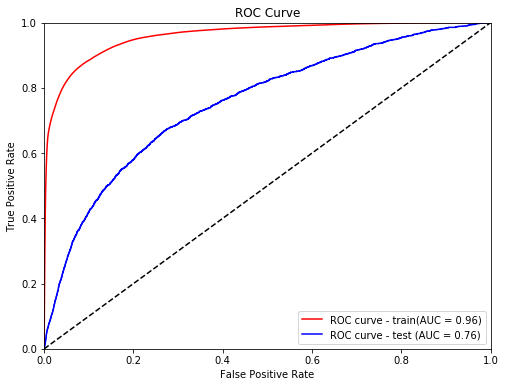

```python
model_eval(cls_final, X_train_s, X_test_s, y_train, y_test, 0.1138)
```

So now we got our final model. There is a trade-off where recall decreases to 0.60 from the last model and the precision increases to 0.04. I think more communications are needed to understand the business goal and adjust the modeling goal accordingly. It has a AUC of 0.76 on test set and an accracy of 0.77.

The precision metric for the model does not look good. We should try to collect more samples for the class of fraud to improve it.

## Feature Importance

We finally settled down on the model. Now we want to take a look at the feature importance plot to identify important features and come up with busines strategies.

The top 10 important features include:

- **cardPresent**: This is a boolean variable showing whether the card is presented when making the transaction. We should be more confident about the transaction if the physical card is showing up along with the customer himself/herself.
- **posEntryMode (05, 09)** and **posConditionCode (08)**: The pos entry code and condition code can be related to fraud cases. We should work with other team members to figure out what those code stand for, and then try to come up with some useful insights.
- **newMerchant**: It is a newly generated feature and it indicates whether the transaction is happening with a brand new merchant that the customer have never shopped with. We should be very careful about those unusual transactions. We can also think about setting up special alarm system for those transactions.
- **transaction_Amount:** We have visualizations above to show that the distributions of transaction amount are different for non-fraud transactions and fraud ones. The fraudulent cases are less likely to have very small or very big amount of money because fraudsters don't want to be too noticable. We should focus on the small-medium amount transactions to detect fraud activities.
- **merchantCategoryCode (online_retail, rideshare, subscriptions, online gifts)**: Whether the transaction happens with one of the 4 merchant categories here can be relevant to decide whether the transaaction is a fraud.

Also, one thing again my intuition is that, I thought the feature `matchCVV` would be an important feature, but it turns out not. Looks like it is common that people have fat fingers:)

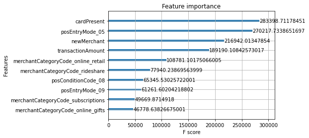

```python
plot_importance(cls_final,importance_type='total_gain', max_num_features=10)
plt.show()
```

# Some Thoughts / Next Steps

If I have more time, here are a few items I think would be worthwhile looking into:

- **Data:**
  - **Imbalance:** The data is imbalanced and some model evaluation metrics do not look good. We should try to find more fraudulent samples in order to build a better model.
  - **Data Dictionary:** The data dictionary is needed here, especially for understanding the pos code.
  - **Missing Values:** We should work with the DE team to understand the reasons for missing values. Is it originally missing in the database or do the missing records have some special meanings?
  - **New Data Sources**: It would be great if we have more features available (creditscore, customer tenure, age, income, and etc.,)
  - **Reserval Transactions Mismatch**: There are 2,547 reversal transactions that I am not able to match with a normal purchase transactions. Probably need to check with DE team as well.
- **Feature Engineering:**
  - **creditlimit:** I notice this field only has limited unique values. We can probably try to treat it as categorical variables instead of numerical to see if anything specifc would jump out.
  - **merchantName:** I converted it a new feature `newMerchant`. I am thinking we could also apply some regular expression replacement and string distance calculation to reduce the dimensionality of the variable and create another new feature.
  - **More feature engineering** can be done here, but we also need be careful for the **data leakage** issue. (For example, I originally planned to add a new feature to show the total number of fraud transactions occured for that each customer, but then I was worried that it would lead to data leakage as it would be an aggregation across the entire table. We could probably change it to the total number of fraud transactions only up to the current transaction.
- **SMOTE**
  - Currently, I am using `SMOTE()` function to oversampling the data and get 50:50 balance. We can also try other methods to keep the as many original tastes of the data as we can (e.g. We can combine the SMOTE with RandomUnderSampler.)
  - Reference: [SMOTE for Imbalanced Classification with Python](https://machinelearningmastery.com/smote-oversampling-for-imbalanced-classification/)
- **Modeling:**
  - **Algorithms:** We could try a few more other advanced models and then compare performance. (such as LightGBM and Random Forest)
  - **Evaluation metrics:** I think we should be focusing on the precision and recall, but it needs to be discussed that which one should be our priority. For example, if the cost of missing a fraud highly outweighs the cost of canceling a bunch of legit customer transactions, i.e. false positives, then perhaps we can choose a weight that gives us a higher recall rate. Or maybe catching 80% of fraud is good enough for your business if you can minimize also minimize the "user friction" or credit card disruptions by keeping our precision high. We could also adjust the weight for f1 score to show the priority.
  - **Validation Set**: Now we only have training and test set in the model. We can add in the validation set and keep the test set completely out of the model building process.
  - **Over-fitting**: Although evaluation metrics do not look too bad, the model still suffers from over-fitting issue. We could try to solve this by introducing more samples, further tuning the hyper-parameters, or dropping some irrelevant features.